# 01 - Initial Data Discovery

Sergi Puigventos Ventura & Daniel Da Graça

2023-06-11

## REFERENCES

List of references:

- Source data [KDD Cup 1999 Data Data Set](https://archive.ics.uci.edu/ml/datasets/kdd+cup+1999+data)
- A Detailed [Analysis of the KDD CUP 99 Data Set](https://www.ecb.torontomu.ca/~bagheri/papers/cisda.pdf)
- KDD [download archive](https://www.kdd.org/kdd-cup/view/kdd-cup-1999/Data)
- Kaggle comunity [notebooks](https://www.kaggle.com/datasets/galaxyh/kdd-cup-1999-data/code) with KDD CUP 99 data set.

## INITIAL ACTIONS

Based on the references we made some initial changes to the data.

1. We added a data set with a categorization of the response variable values, the attack types (https://kdd.org/cupfiles/KDDCupData/1999/training_attack_types), having in mind two potential uses as,
   - on one side, the model derivation could benefit from having a smaller set of values to target
   - and, on the other, we could potentially generate additional response variables considering there could be features relating specifically to some attack types but not others and it could then be easier to derive a specific model having specific response variable to target.
2. A reference table with for each of the main data set features:
   - the feature name from the data set header record,
   - the data type returned by the R command str(),
   - the kddcup.names (http://kdd.org/cupfiles/KDDCupData/1999/kddcup.names) for the statistical type
   - and a functional description provided by chatGPT.
3. Addition of the following response variables:
   - **AttackCat**: “Category type of the attacks: DoS, Probe, Normal, U2R, L2R, Others”
   - **IsAttack**: “Boolean flag indicating whether an attack was observed.”
   - **IsDosAttack**: “Boolean flag indicating whether a DOS attack was observed.”
   - **IsProbeAttack**: “Boolean flag indicating whether a Probe attack was observed.”
   - **IsR2Lattack**: “Boolean flag indicating whether a R2L attack was observed.”
   - **IsU2Rattack**: “Boolean flag indicating whether a U2R attack was observed.”
   - **IsOtherAttack**: “Boolean flag indicating whether an unclassified (other) attack was observed.”  
     The reason to derive those binary response variables with 1 or 0 is anticipating that we could then look for correlations whether with the numerical continuous features or categorical ones (with Chi Square).
4. We also remove the dot (“.”) from the “Attack” response variable and run the unique() function on the training data.frame to remove eventually duplicated rows

## EXPLORATION OF THE TRAINING DATASET

With this section, the intention is to try to automate “a first glimpse” of the data .

In summary what it does is looping through all the dataset features in order to identify for each one:

- if it holds missing values and how many,
- basic statistics for quantitative numeric variables,
- and the distribution of values of the feature.

```
##
## ------------------------------------------------------------------------------------
##  Details of feature 1 [ Duration ]:
##
##    Data type: int
##    Statistical type: continuous
##    Field Description: The duration of the connection in seconds. It represents the length of time the connection lasted.
##
##    -> Number of Missing values: 0
##    -> Value Minimum:[ 0 ], Value Maximum:[ 57715 ]
##
##  Vals  Freq PctOfObs
##     0 72141 93.337 %
##     1  1316  1.703 %
##     4   623  0.806 %
##   282   250  0.323 %
##   280   243  0.314 %
##     3   234  0.303 %
##     2   204  0.264 %
##     5   182  0.235 %
##   281   154  0.199 %
##   283    89  0.115 %
##     6    66  0.085 %
##     7    36  0.047 %
##   805    32  0.041 %
##     9    30  0.039 %
##     8    29  0.038 %
##    21    28  0.036 %
##   902    28  0.036 %
##    20    24  0.031 %
##    10    22  0.028 %
##   284    21  0.027 %
##    23    18  0.023 %
##   903    18  0.023 %
##   898    17  0.022 %
##    11    16  0.021 %
##    25    16  0.021 %
##    27    16  0.021 %
##    28    15  0.019 %
##   801    15  0.019 %
##    26    14  0.018 %
##   796    14  0.018 %
## ... [ 715 more]
##
##    -> Interquartile difference:[ 0 ]
##       Requires looking for skewness!
##
##     Min.  1st Qu.   Median     Mean  3rd Qu.     Max.
##     0.00     0.00     0.00    70.76     0.00 57715.00
```

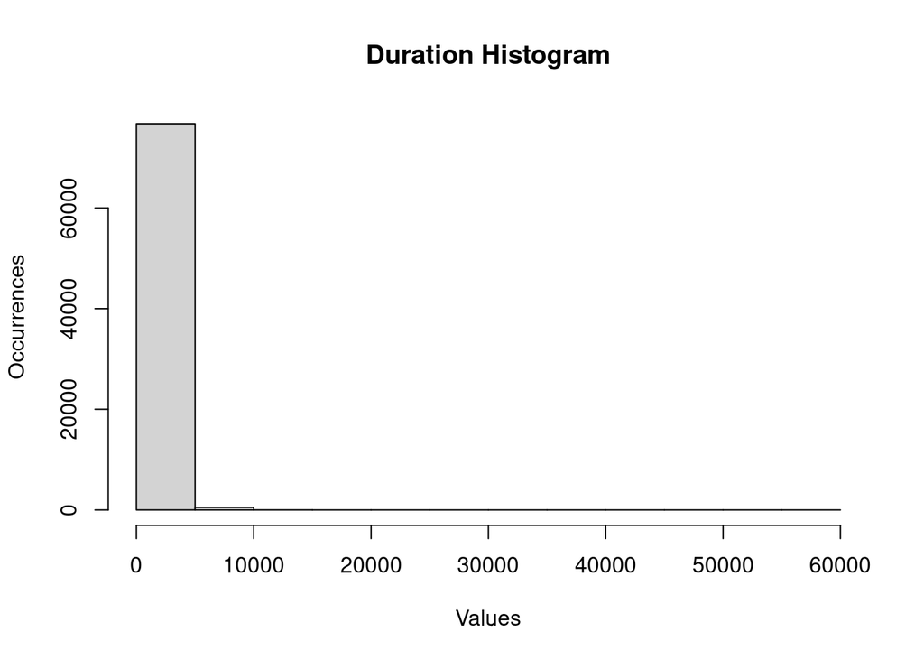

```
##
## ------------------------------------------------------------------------------------
##  Details of feature 2 [ ProtocolType ]:
##
##    Data type: chr
##    Statistical type: symbolic
##    Field Description: The protocol type of the network connection, such as TCP, UDP, ICMP, etc. It indicates the communication protocol used in the connection.
##
##    -> Number of Missing values: 0
##    -> Value Minimum:[ icmp ], Value Maximum:[ udp ]
##
##  Vals  Freq PctOfObs
##   tcp 71124 92.021 %
##   udp  4692  6.071 %
##  icmp  1475  1.908 %
```

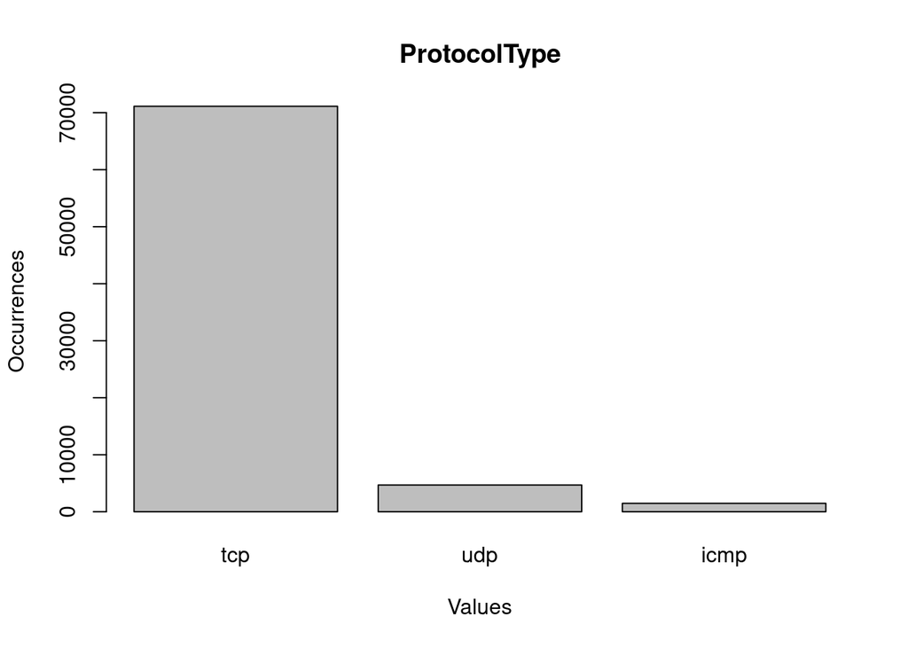

```
##
## ------------------------------------------------------------------------------------
##  Details of feature 3 [ Service ]:
##
##    Data type: chr
##    Statistical type: symbolic
##    Field Description: The specific service or application associated with the network connection, such as http, ftp, smtp, etc. It represents the service or application layer protocol running on top of the network protocol.
##
##    -> Number of Missing values: 0
##    -> Value Minimum:[ auth ], Value Maximum:[ Z39_50 ]
##
##        Vals  Freq PctOfObs
##        http 40350 52.205 %
##     private 19291 24.959 %
##        smtp  3574  4.624 %
##    domain_u  2622  3.392 %
##      telnet  1792  2.319 %
##    ftp_data  1637  2.118 %
##       pop_3  1135  1.468 %
##       ecr_i  1110  1.436 %
##       other  1038  1.343 %
##         ftp   818  1.058 %
##       imap4   331  0.428 %
##       eco_i   300  0.388 %
##      finger   291  0.376 %
##      sunrpc   193   0.25 %
##        auth   148  0.191 %
##        time    78  0.101 %
##        echo    69  0.089 %
##      domain    68  0.088 %
##         bgp    66  0.085 %
##        link    66  0.085 %
##      gopher    65  0.084 %
##     netstat    65  0.084 %
##  remote_job    65  0.084 %
##  netbios_ns    64  0.083 %
##         ctf    63  0.082 %
##    iso_tsap    62   0.08 %
##        nntp    62   0.08 %
##       ntp_u    62   0.08 %
##        uucp    62   0.08 %
##        exec    61  0.079 %
## ... [ 35 more]
```

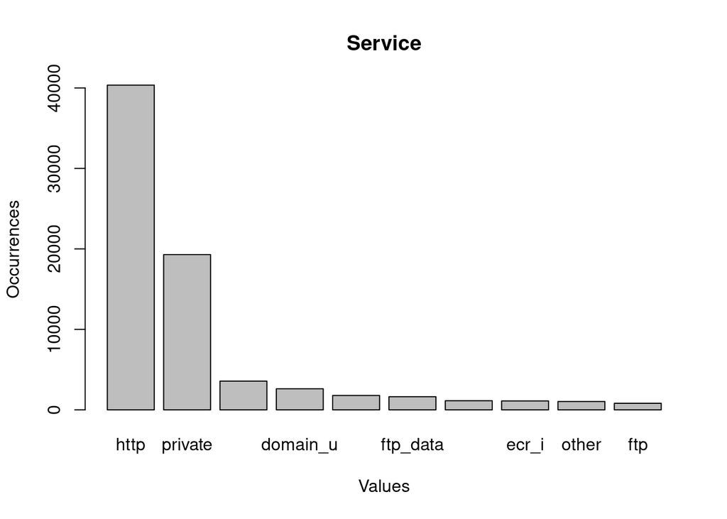

```
##
## ------------------------------------------------------------------------------------
##  Details of feature 4 [ Flag ]:
##
##    Data type: chr
##    Statistical type: symbolic
##    Field Description: Represents the status of the connection, indicating whether it is normal or if specific flags are set in the network packets. It provides information about the connection status, such as whether it is established, closed, or has certain flags set.
##
##    -> Number of Missing values: 0
##    -> Value Minimum:[ OTH ], Value Maximum:[ SH ]
##
##    Vals  Freq PctOfObs
##      SF 53624 69.379 %
##     REJ 13988 18.098 %
##      S0  7172  9.279 %
##    RSTO  1380  1.785 %
##    RSTR   718  0.929 %
##      S3   274  0.355 %
##      SH    80  0.104 %
##      S1    27  0.035 %
##      S2    22  0.028 %
##     OTH     4  0.005 %
##  RSTOS0     2  0.003 %
```

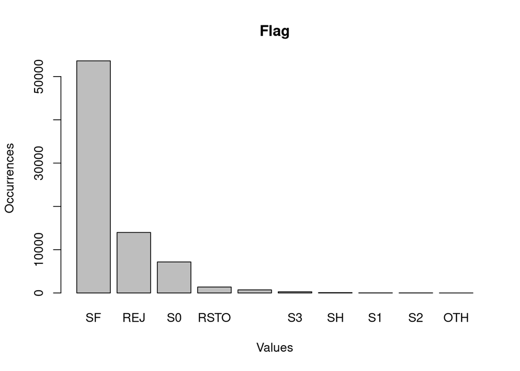

```
##
## ------------------------------------------------------------------------------------
##  Details of feature 5 [ SrcBytes ]:
##
##    Data type: int
##    Statistical type: continuous
##    Field Description: The number of data bytes transferred from source to destination. They indicate the amount of data transferred between the source and destination hosts.
##
##    -> Number of Missing values: 0
##    -> Value Minimum:[ 0 ], Value Maximum:[ 62825648 ]
##
##   Vals  Freq PctOfObs
##      0 23916 30.943 %
##     44   649   0.84 %
##      1   527  0.682 %
##     42   527  0.682 %
##     45   526  0.681 %
##   1032   518   0.67 %
##    105   499  0.646 %
##    221   460  0.595 %
##    220   439  0.568 %
##    205   398  0.515 %
##    222   392  0.507 %
##    223   389  0.503 %
##    204   380  0.492 %
##    232   380  0.492 %
##    219   374  0.484 %
##    208   371   0.48 %
##    218   370  0.479 %
##    215   367  0.475 %
##    225   363   0.47 %
##    224   359  0.464 %
##    293   355  0.459 %
##    305   353  0.457 %
##  54540   349  0.452 %
##    229   348   0.45 %
##    307   348   0.45 %
##    226   344  0.445 %
##    216   342  0.442 %
##    231   341  0.441 %
##     30   340   0.44 %
##    230   340   0.44 %
## ... [ 2474 more]
##
##    -> Interquartile difference:[ 296 ]
##     Min.  1st Qu.   Median     Mean  3rd Qu.     Max.
##        0        0      211     3428      296 62825648
```

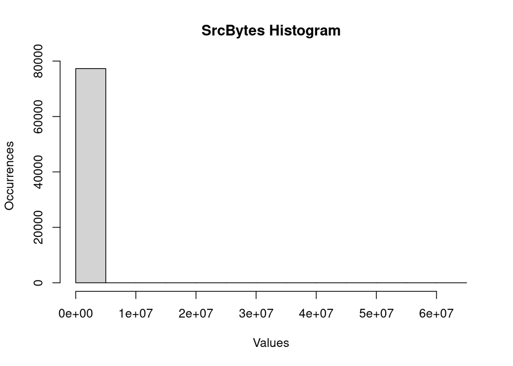

```
##
## ------------------------------------------------------------------------------------
##  Details of feature 6 [ DstBytes ]:
##
##    Data type: int
##    Statistical type: continuous
##    Field Description: The number of data bytes transferred from destination to source. They indicate the amount of data transferred between the destination and source hosts.
##
##    -> Number of Missing values: 0
##    -> Value Minimum:[ 0 ], Value Maximum:[ 5203179 ]
##
##  Vals  Freq PctOfObs
##     0 26885 34.784 %
##    44   988  1.278 %
##    93   766  0.991 %
##    42   454  0.587 %
##     1   403  0.521 %
##   174   367  0.475 %
##  8314   343  0.444 %
##   330   322  0.417 %
##   293   316  0.409 %
##   331   270  0.349 %
##   332   265  0.343 %
##   327   236  0.305 %
##   597   225  0.291 %
##    15   221  0.286 %
##    83   211  0.273 %
##   333   207  0.268 %
##   329   206  0.267 %
##   146   199  0.257 %
##    45   185  0.239 %
##   334   184  0.238 %
##   328   176  0.228 %
##    36   152  0.197 %
##   313   149  0.193 %
##   599   146  0.189 %
##   337   143  0.185 %
##  2698   143  0.185 %
##   335   140  0.181 %
##   336   136  0.176 %
##   263   135  0.175 %
##    43   132  0.171 %
## ... [ 9172 more]
##
##    -> Interquartile difference:[ 1774 ]
##    Min. 1st Qu.  Median    Mean 3rd Qu.    Max.
##       0       0     321    2871    1774 5203179
```

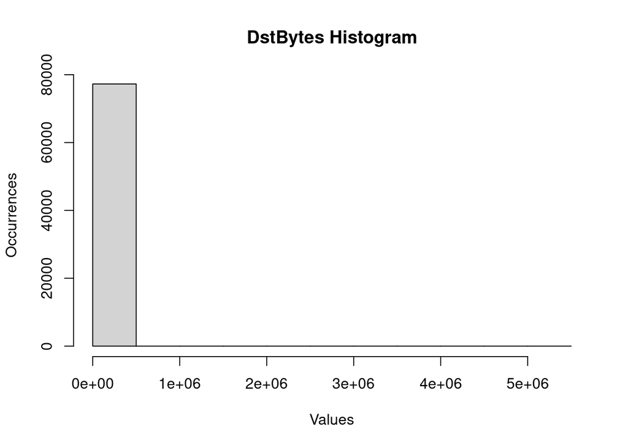

```
##
## ------------------------------------------------------------------------------------
##  Details of feature 7 [ Land ]:
##
##    Data type: int
##    Statistical type: symbolic
##    Field Description: Indicates whether the connection is from/to the same host/port (land attack). It is a binary field that indicates if the connection is a "land" attack, where the source and destination IP addresses and ports are the same.
##
##    -> Number of Missing values: 0
##    -> Value Minimum:[ 0 ], Value Maximum:[ 1 ]
##
##  Vals  Freq PctOfObs
##     0 77282 99.988 %
##     1     9  0.012 %
```

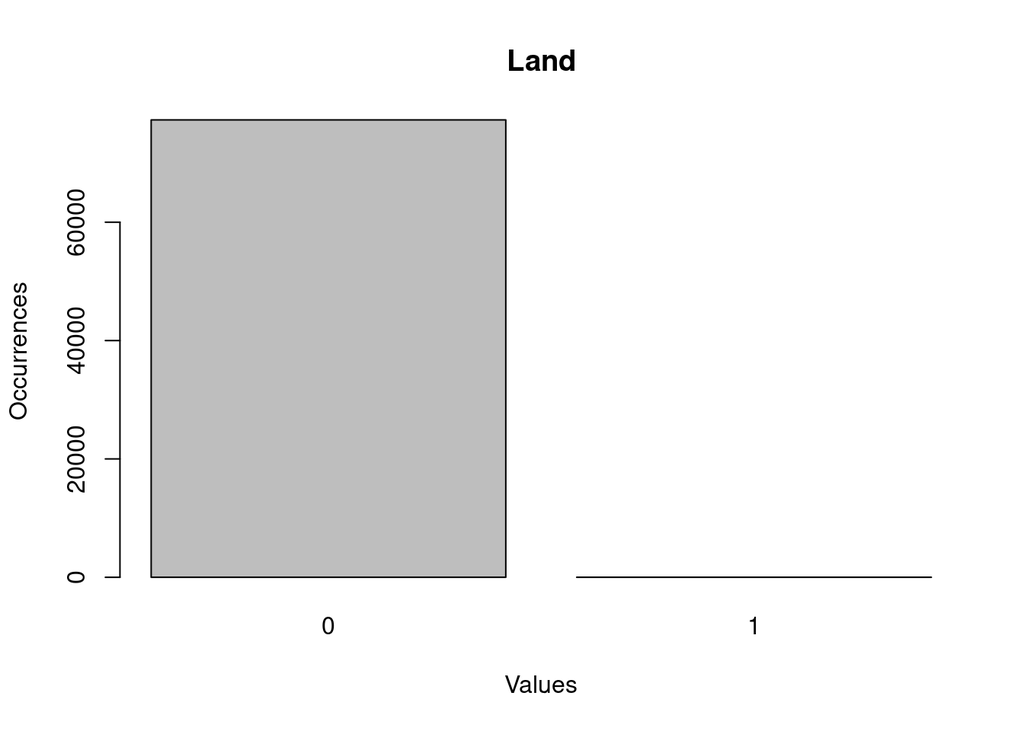

```
##
## ------------------------------------------------------------------------------------
##  Details of feature 8 [ WrongFragment ]:
##
##    Data type: int
##    Statistical type: continuous
##    Field Description: The number of wrong fragments received or sent. It represents the count of improperly formed or malformed IP fragments.
##
##    -> Number of Missing values: 0
##    -> Value Minimum:[ 0 ], Value Maximum:[ 3 ]
##
##  Vals  Freq PctOfObs
##     0 77185 99.863 %
##     1    61  0.079 %
##     3    45  0.058 %
##
##    -> Interquartile difference:[ 0 ]
##       Requires looking for skewness!
##
##     Min.  1st Qu.   Median     Mean  3rd Qu.     Max.
## 0.000000 0.000000 0.000000 0.002536 0.000000 3.000000
```

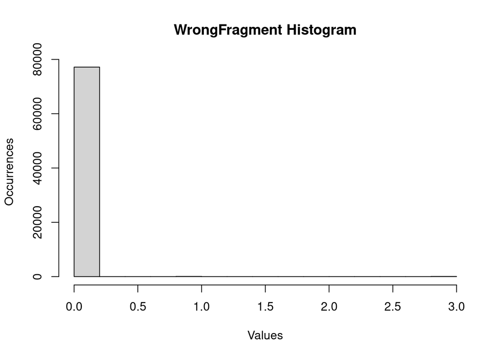

```
##
## ------------------------------------------------------------------------------------
##  Details of feature 9 [ Urgent ]:
##
##    Data type: int
##    Statistical type: symbolic
##    Field Description: The number of urgent packets. It indicates the number of packets with the urgent bit set.
##
##    -> Number of Missing values: 0
##    -> Value Minimum:[ 0 ], Value Maximum:[ 3 ]
##
##  Vals  Freq PctOfObs
##     0 77281 99.987 %
##     1     5  0.006 %
##     2     4  0.005 %
##     3     1  0.001 %
```

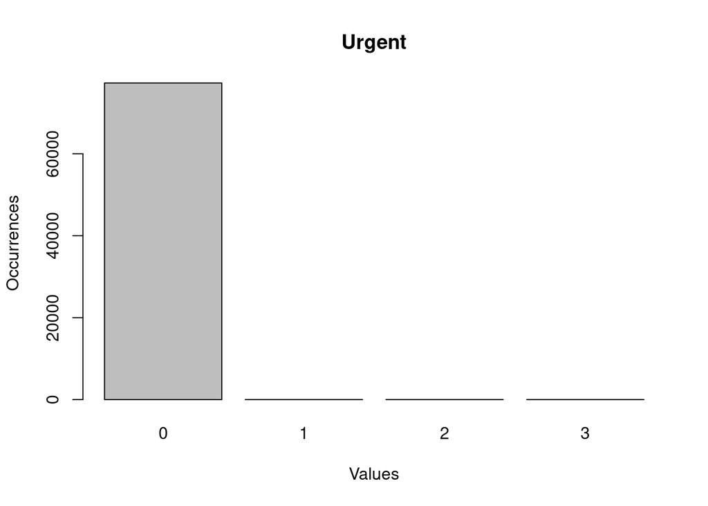

```
##
## ------------------------------------------------------------------------------------
##  Details of feature 10 [ Hot ]:
##
##    Data type: int
##    Statistical type: continuous
##    Field Description: Indicates whether the login belongs to a "hot" list, which is a list of hosts that are considered potentially vulnerable or suspicious.
##
##    -> Number of Missing values: 0
##    -> Value Minimum:[ 0 ], Value Maximum:[ 101 ]
##
##  Vals  Freq PctOfObs
##     0 76123 98.489 %
##     2   902  1.167 %
##     1   121  0.157 %
##     4    54   0.07 %
##     5    24  0.031 %
##     6    14  0.018 %
##     3    12  0.016 %
##     7    12  0.016 %
##    18     7  0.009 %
##    19     6  0.008 %
##    22     4  0.005 %
##    24     3  0.004 %
##    10     2  0.003 %
##    14     2  0.003 %
##    30     2  0.003 %
##    11     1  0.001 %
##    15     1  0.001 %
##   101     1  0.001 %
##
##    -> Interquartile difference:[ 0 ]
##       Requires looking for skewness!
##
##      Min.   1st Qu.    Median      Mean   3rd Qu.      Max.
##   0.00000   0.00000   0.00000   0.04011   0.00000 101.00000
```

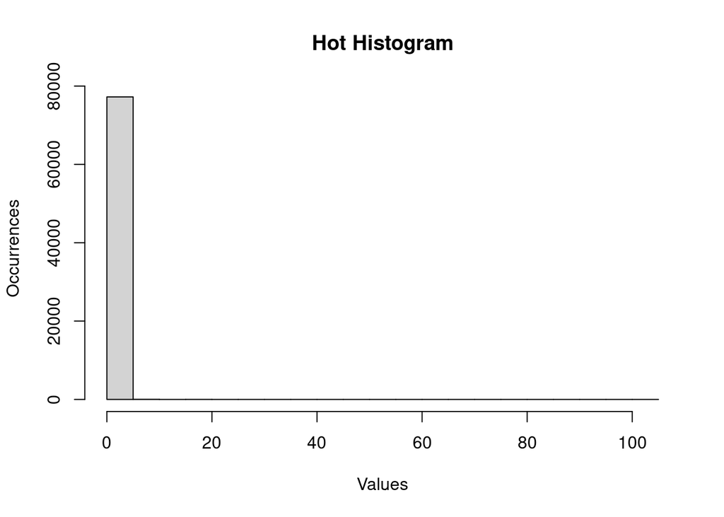

```
##
## ------------------------------------------------------------------------------------
##  Details of feature 11 [ NumFailedLogin ]:
##
##    Data type: int
##    Statistical type: symbolic
##    Field Description: The number of failed login attempts. It represents the count of failed login attempts in the session.
##
##    -> Number of Missing values: 0
##    -> Value Minimum:[ 0 ], Value Maximum:[ 4 ]
##
##  Vals  Freq PctOfObs
##     0 76797 99.361 %
##     1   488  0.631 %
##     3     3  0.004 %
##     4     2  0.003 %
##     2     1  0.001 %
```

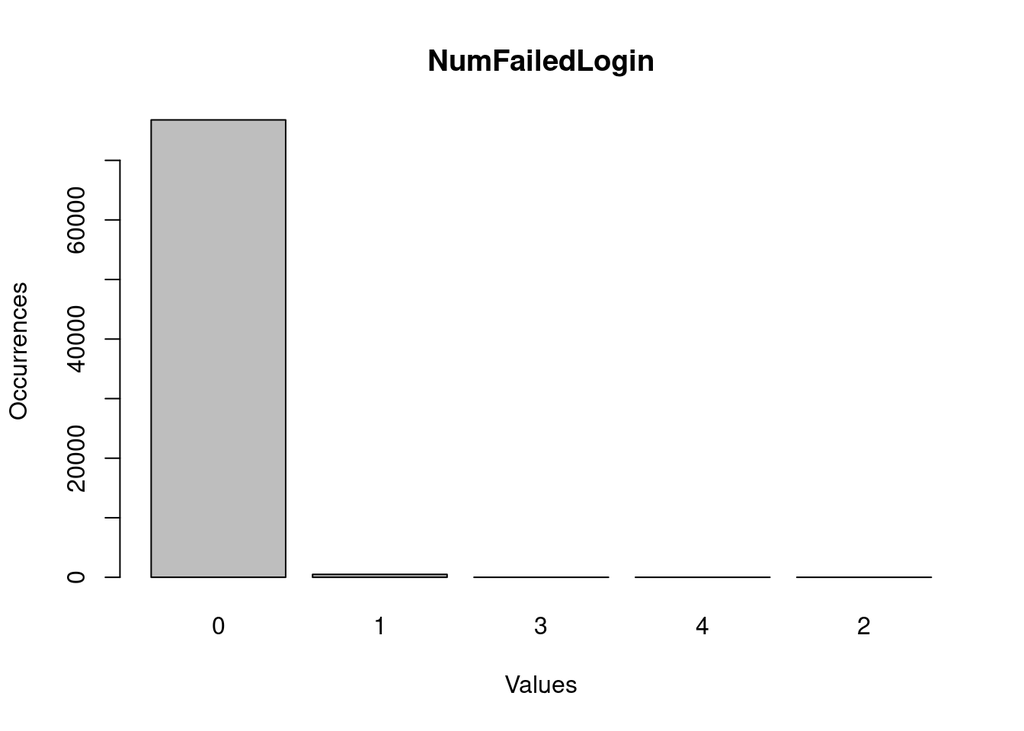

```
##
## ------------------------------------------------------------------------------------
##  Details of feature 12 [ LoggedIn ]:
##
##    Data type: int
##    Statistical type: symbolic
##    Field Description: Indicates whether the login was successfully performed. It is a binary field that indicates if the login was successful or not.
##
##    -> Number of Missing values: 0
##    -> Value Minimum:[ 0 ], Value Maximum:[ 1 ]
##
##  Vals  Freq PctOfObs
##     1 45214 58.498 %
##     0 32077 41.502 %
```

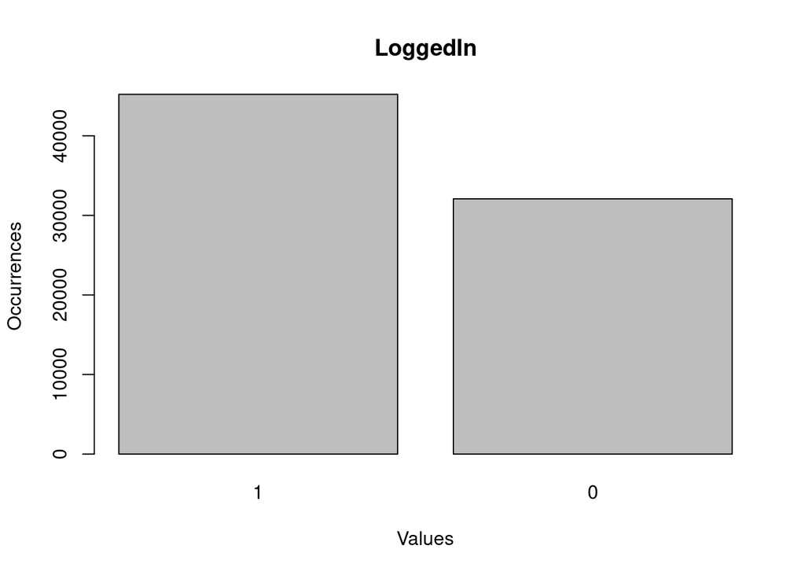

```
##
## ------------------------------------------------------------------------------------
##  Details of feature 13 [ NumCompromised ]:
##
##    Data type: int
##    Statistical type: continuous
##    Field Description: The number of compromised conditions. It represents the count of compromised conditions in the session.
##
##    -> Number of Missing values: 0
##    -> Value Minimum:[ 0 ], Value Maximum:[ 796 ]
##
##  Vals  Freq PctOfObs
##     0 76882 99.471 %
##     1   354  0.458 %
##     2    13  0.017 %
##     3     7  0.009 %
##     4     5  0.006 %
##     8     4  0.005 %
##     5     3  0.004 %
##     6     3  0.004 %
##     7     3  0.004 %
##    14     2  0.003 %
##    49     2  0.003 %
##     9     1  0.001 %
##    10     1  0.001 %
##    11     1  0.001 %
##    15     1  0.001 %
##    16     1  0.001 %
##    23     1  0.001 %
##    25     1  0.001 %
##    36     1  0.001 %
##    57     1  0.001 %
##   165     1  0.001 %
##   381     1  0.001 %
##   611     1  0.001 %
##   796     1  0.001 %
##
##    -> Interquartile difference:[ 0 ]
##       Requires looking for skewness!
##
##     Min.  1st Qu.   Median     Mean  3rd Qu.     Max.
##   0.0000   0.0000   0.0000   0.0361   0.0000 796.0000
```

[36 more figures not shown]

```r
if(readingdataOK)
{
    for(i in 1:ncols) {
        current_feature <- features[i,1]
        df <- data.frame(data[ , i], data$Attack, data$AttackCat, data$IsAttack, data$IsDosAttack, data$IsProbeAttack
                         , data$IsR2Lattack, data$IsU2Rattack, data$IsOtherAttack)
        colnames(df) <- c(current_feature, 'Attack', 'AttackCat', 'IsAttack', 'IsDosAttack', 'IsProbeAttack'
                          , 'IsR2Lattack', 'IsU2Rattack', 'IsOtherAttack')
        minval <- min(df[ , 1])
        maxval <- max(df[ , 1])
        cat(paste('\n------------------------------------------------------------------------------------\n'
                  , 'Details of feature', i, '[', features[i,1], ']:\n'), fill = TRUE)
        cat(paste('   Data type:', features[i, 2]), fill = TRUE)
        cat(paste('   Statistical type:', features[i, 3]), fill = TRUE)
        cat(paste('   Field Description:', features[i, 4], '\n'), fill = TRUE)
        nmissingvals <- sum(is.na(df[ , 1])) # 'is.finite()' function is used to identify non-NA and non-NaN values
        cat(paste('   -> Number of Missing values:', nmissingvals), fill = TRUE)
        cat(paste('   -> Value Minimum:[', minval, '], Value Maximum:[', maxval, ']\n'), fill = TRUE)
        if(minval == maxval){
            print('      Both minimum and maximum values are the same! The feature can potentially be discarded.\n'
                  , row.names = FALSE)
        }else {

            values <- levels(factor(df[ , 1])) # Getting the values
            values.dis <- data.frame(table(df[ , 1])) # Getting values distribution
            colnames(values.dis)[1] <- "Vals"
            colnames(values.dis)[2] <- "Freq"
            nvals <- nrow(values.dis)
            values.dis <- values.dis[order(values.dis$Freq, decreasing=TRUE),]
            for(vd in 1:min(nvals, 30)){
                values.dis$PctOfObs <- paste(round(values.dis$Freq/nrows*100, digits = 3), '%')}
            #print(knitr::kable(values.dis[1:min(nvals, 30),]), row.names = FALSE)
            print(values.dis[1:min(nvals, 30),], row.names = FALSE)
            if(nvals >= 30){
                cat(paste("... [", (nvals-30), "more]" ), fill = TRUE)}

            # Plotting the distribution of the features
            if (features[i, 3] == 'symbolic' || features[i, 3] == 'response'){
                if(nvals >= 10){
                    barplot(values.dis$Freq[1:10], names.arg = values.dis$Vals[1:10],
                            xlab = "Values", ylab = "Occurrences", main = current_feature)
                }else{
                    barplot(values.dis$Freq, names.arg = values.dis$Vals,
                            xlab = "Values", ylab = "Occurrences", main = current_feature)
                }
            }else{
                stdev <- sd(df[ , 1])
                if(stdev == 0){
                    print('   Standard Deviation is 0 for the feauture. It does not represent statistical interest.\n'
                          , row.names = FALSE)
                }else{
                    interquartile <- IQR(df[ , 1])
                    cat(paste('\n   -> Interquartile difference:[', interquartile, ']'), fill = TRUE)
                    if(interquartile == 0){cat('      Requires looking for skewness!\n', fill = TRUE)}
                    #print(paste(str(df[ , 1])), row.names = FALSE)
                    print(summary(df[ , 1]), row.names = FALSE)
                    hist(df[ , 1], main = paste(current_feature, "Histogram"), xlab = "Values", ylab = "Occurrences")
                }
            }
        }
    }
}
```

## TRYING TO UNDERSTAND CORRELATIONS BETWEEN **NUMERIC** FEATURES

To find out correlations between numeric variables, we used the cor() function (based on advice from chatGPT answering the question: *“How to find out about correlations between variables?”*).

- The cor(data.frame()) expression calculates correlation coefficients which measure the linear association between columns of a data frame.
- The correlation coefficients range from -1 to +1, where -1 indicates a perfect negative linear relationship, +1 indicates a perfect positive linear relationship, and 0 indicates no linear relationship.

ChatGPT helped a bit further with its answers to the question *“What minimum Pearson’s coefficient value, positive or negative, is required to consider that a relation exists between two variables?”*

1. “**Magnitude of the correlation coefficient:** The absolute value of the correlation coefficient (r) indicates the strength of the relationship. Typically, values closer to 1 (either positive or negative) indicate a stronger relationship, while values closer to 0 suggest a weaker relationship. As a rough guideline, correlations with an absolute value above 0.5 or 0.6 are often considered moderate to strong, while those below 0.3 are considered weak.”
2. “**Statistical significance:** In addition to the magnitude of the correlation coefficient, it’s important to assess statistical significance. The p-value associated with the correlation coefficient indicates whether the observed correlation is statistically significant or could have occurred by chance. Generally, a p-value below a predetermined threshold (e.g., 0.05) is considered statistically significant, indicating a higher confidence in the presence of a true relationship.”

The cor() function provides as result a correlation square matrix where each element represents the correlation between two variables and which we then parse and insert into a dataframe which purpose will be to hold all feature pair relations analysis.

```r
# Identifying columns with zero standard deviation in order to discard them
featuresToDiscard <- data.frame(Feature = c(), Reason = c())
numericFeaturesToKeep <- colnames(select_if(data, is.numeric))
numericFeaturesToDiscard <- colnames(select_if(select_if(data, is.numeric), function(x) sd(x) == 0))
for(f in 1:length(numericFeaturesToDiscard)){
    numericFeaturesToKeep <- numericFeaturesToKeep[numericFeaturesToKeep != numericFeaturesToDiscard[f]]
    featuresToDiscard <- rbind(featuresToDiscard, data.frame(Feature = numericFeaturesToDiscard[f]
                                                             , Reason = 'Standard deviation = 0'))
}

# Identifying correlations between numeric variables that will help to
# - determine relationships with the response variables
# - and relationships between variables that could then be summarized/reduced to one feature
corrs <- data.frame(feature1 = c(), feature2 = c(), coefficient = c(), pvalue = c(), interpretation = c()
                    , toIgnore = c(), method = c())
corrmatrix <- corr.test(data[, names(data) %in% numericFeaturesToKeep])
corrmatrixvars <- colnames(corrmatrix$r)
for(c in 1:ncol(corrmatrix$r)){
    for(r in c:nrow(corrmatrix$r))
    {
        if(features[features$Feature == corrmatrixvars[c], 3] != 'response'      # Discarding looking for correlations
           || features[features$Feature == corrmatrixvars[r], 3] != 'response')  # between response variables
        {
            pearsoncoef <- round(corrmatrix$r[r, c], digits = 10)
            pval <- round(corrmatrix$p[r, c], digits = 10)
            toignore <- 'No'
            if (abs(pearsoncoef) >= 0.7 && pval <= 0.05) {
                interpretation <- "Strong correlation"
            } else if (abs(pearsoncoef) >= 0.5 && pval <= 0.05) {
                interpretation <- "Good correlation"
            } else if (abs(pearsoncoef) >= 0.3 && pval <= 0.05) {
                interpretation <- "Some correlation"
            } else {
                interpretation <- "Weak or no correlation"
                toignore <- 'Yes'
            }
            if(corrmatrixvars[c] != corrmatrixvars[r] && is.na(pearsoncoef) == FALSE) {
                corrs <- rbind(corrs, data.frame(feature1 = corrmatrixvars[c]
                                                 , feature2 = corrmatrixvars[r]
                                                 , coefficient = pearsoncoef
                                                 , pvalue = pval
                                                 , interpretation = interpretation
                                                 , toIgnore = toignore
                                                 , method = 'Correlation Test'))
            }
        }
    }
}

corrs <- corrs[order(desc(corrs$coefficient), corrs$pvalue), 1:7]

#print(numericFeaturesToKeep[v])
#par(mar = c(0.5, 0.5, 0.5, 0.5))  # Adjusting the plot margin size
#for(v in 1:(length(numericFeaturesToKeep)-nrespvars)){

#    df <- data.frame(data[ , numericFeaturesToKeep[v]], data$IsAttack, data$IsDosAttack, data$IsProbeAttack
#                     , data$IsR2Lattack, data$IsU2Rattack, data$IsOtherAttack)
#    pairs(df, pch = 20, col = "blue", main = paste("Scatter Plot Matrix for", numericFeaturesToKeep[v])
#                                                   , "and the numeric response variables")
#}
                # Scatter plot that could help identify correlations between the current feature and the numeric response vars
                #cat(paste('\n   -> Scatter plot for', current_feature, 'and the numeric response variables:'), fill = TRUE)
                #ggplot(data = df) +
                #        geom_point(aes(x = current_feature, y = .)) +
                #        geom_smooth(aes(x = current_feature, y = .)) +
                #        facet_wrap(~ colnames(df)[2], scales = "free") +
                #        labs(x = current_feature, y = "Response Variable", title = "Scatter Plot")
```

## TRYING TO UNDERSTAND CORRELATIONS BETWEEN **CATEGORICAL** FEATURES USING CHI-SQUARE TEST

To find out correlations between categorical variables, we used the chisq.test() function (based on advice from chatGPT answering the question: *“How to get a correlation for categorical variables??”*).

- “The result of the chisq.test() function includes the chi-squared test statistic and the associated p-value. The p-value indicates the level of significance and helps determine whether the observed association is statistically significant. A small p-value (typically below a chosen significance level, such as 0.05) suggests evidence against the null hypothesis of independence or goodness-of-fit.” (chatGPT)
- “However, the chisq.test() function does not provide a coefficient that directly measures the strength or magnitude of the association between variables. It primarily focuses on the statistical significance of the association.”
- So, querying chatGPT about “*how to measure the correlation between categorical variables*”, it suggested to use the ‘vcd’ package to get the following coefficients.
  - 1. **Cramér’s V**: Cramér’s V is a measure of association between two categorical variables. It takes into account the dimensions of the contingency table and ranges from 0 to 1, where 0 indicates no association and 1 indicates a strong association.
  - 2. **Phi coefficient**: The phi coefficient is another measure of association for a 2x2 contingency table. It ranges from -1 to 1, where 0 indicates no association, positive values indicate positive association, and negative values indicate negative association.
  - 3. **Contingency coefficient**: The contingency coefficient is a measure of association for contingency tables of any size. It ranges from 0 to 1, where 0 indicates no association and 1 indicates a perfect association.

This chisq.text() function does not take a data frame as input so it has been necessary to loop through all feature pairs in order to run the function for each. Nonetheless we filtered out the numerical features and the constants, so that we’d run it only for variables worth it and of course only for the categorical ones.

Then the results are loaded into the same correlation table as the one holding the results of the correlation test of numerical features. * It is a table where each row contains the pair of features which association level is tested, * along with the coefficient allowing to measure the relation strength, * the P-Value indicating whether the relation is statistically significant, * an automated interpretation qualifying the relation taking into account the coefficient and of the p-value, * a generated flag indicating whether the pair association is to be ignored because insignificant * and the method used for the correlation, either the chi-square for categorical features or the correlation test for numeric ones.

Finally, the data frame is sorted by the coefficient in descending order and the p-value ascending to get the highest correlations at both the top and the bottom of the table (negative correlations).

```r
# Identifying correlations between categorical variables with CHI-SQUARE test that will help to
# - determine relationships with the response variables
# - and relationships between the categorical variables that could then be summarized/reduced to one feature
for(c1 in 1:nfeatures){
    minval <- min(data[ , c1])
    maxval <- max(data[ , c1])
    if(minval != maxval){
        if(features[c1, 3] == 'symbolic'){
            for(c2 in (c1+1):nfeatures){
                if(features[c2, 3] == 'symbolic' || features[c2, 3] == 'response' )
                {
                    toignore <- 'No'
                    tab <- table(data[ , c1], data[ , c2])
                    chi_square_test <- suppressWarnings(chisq.test(tab))
                    chi_square_test$data.name <- paste(features$Feature[c1], '/', features$Feature[c2])
                    pval <- round(chi_square_test$p.value, digits = 10) # Extracting the p-value
                    association_stats <- assocstats(tab)
                    cramers_v <- association_stats$cramer
                    contingency_coef <- association_stats$contingency.coef
                    phi_coefficient <- association_stats$phi
                    if(is.na(cramers_v) || is.null(cramers_v)){
                        cramers_v <- 0
                    }else {
                        cramers_v <- round(cramers_v, digits = 10)
                        coefficients <- paste('Cramers-V:', cramers_v)
                    }
                    if(is.na(contingency_coef) || is.null(contingency_coef)){
                        contingency_coef <- 0
                    }else {
                        contingency_coef <- round(contingency_coef, digits = 10)
                        coefficients <- paste(coefficients, ', Contingency Coef.:', contingency_coef)
                    }
                    if(is.na(phi_coefficient) || is.null(phi_coefficient)){
                        phi_coefficient <- 0
                    }else {
                        phi_coefficient <- round(phi_coefficient, digits = 10)
                        coefficients <- paste(coefficients, ', Phi Coef.:', phi_coefficient)
                    }
                    if(cramers_v >= max(contingency_coef, abs(phi_coefficient))){
                        coef <- cramers_v
                    }else if(contingency_coef >= max(cramers_v, abs(phi_coefficient))){
                        coef <- contingency_coef
                    }else{
                        coef <- phi_coefficient
                    }
                    # Interpretation
                    if (pval <= 0.05 && pval >= 0) {
                        if(cramers_v == 1 && contingency_coef == 1 && abs(phi_coefficient) == 1){
                            interpretation <- paste("All signs of a PERFECT association (", coefficients, ')')
                        }else if(cramers_v == 1 || contingency_coef == 1 || abs(phi_coefficient) == 1){
                            interpretation <- paste("Some signs of a PERFECT association (", coefficients, ')')
                        }else if(cramers_v >= 0.7 && contingency_coef >= 0.7 && abs(phi_coefficient) >= 0.7){
                            interpretation <- paste("All signs of a STRONG association (", coefficients, ')')
                        }else if(cramers_v >= 0.7 || contingency_coef >= 0.7 || abs(phi_coefficient) >= 0.7){
                            interpretation <- paste("Some signs of a STRONG association (", coefficients, ')')
                        }else if(cramers_v >= 0.5 && contingency_coef >= 0.5 && abs(phi_coefficient) >= 0.5){
                            interpretation <- paste("All signs of a GOOD association (", coefficients, ')')
                        }else if(cramers_v >= 0.5 || contingency_coef >= 0.5 || abs(phi_coefficient) >= 0.5){
                            interpretation <- paste("Some signs of a GOOD association (", coefficients, ')')
                        }else if(cramers_v >= 0.3 && contingency_coef >= 0.3 && abs(phi_coefficient) >= 0.3){
                            interpretation <- paste("All signs of a MODERATE association (", coefficients, ')')
                        }else if(cramers_v >= 0.3 || contingency_coef >= 0.3 || abs(phi_coefficient) >= 0.3){
                            interpretation <- paste("Some signs of a MODERATE association (", coefficients, ')')
                        }else if(cramers_v >= 0.1 && contingency_coef >= 0.1 && abs(phi_coefficient) >= 0.3){
                            interpretation <- paste("All signs of a WEAK association (", coefficients, ')')
                        }else if(cramers_v >= 0.3 || contingency_coef >= 0.3 || abs(phi_coefficient) >= 0.3){
                            interpretation <- paste("Some signs of a WEAK association")
                        }else{
                            interpretation <- paste("No signs of association (", coefficients, ')')
                            toignore <- 'Yes'
                        }
                    }else {
                            interpretation <- 'No signs of association - P-Value > 0.05'
                            toignore <- 'Yes'
                    }

                    corrs <- rbind(corrs, data.frame(feature1 = features$Feature[c1]
                                                     , feature2 = features$Feature[c2]
                                                     , coefficient = coef
                                                     , pvalue = pval
                                                     , interpretation = interpretation
                                                     , toIgnore = toignore
                                                     , method = 'Chi-Square Test'))

                }
            }
        }
    }else{
        if(nrow(featuresToDiscard[featuresToDiscard$Feature == features$Feature[c1],]) == 0){
            featuresToDiscard <- rbind(featuresToDiscard, data.frame(Feature = features$Feature[c1]
                                                                    , Reason = paste('The value is unique ['
                                                                                     , minval,']')))
        }
    }
}

corrs <- corrs[order(desc(corrs$coefficient), corrs$pvalue), 1:7]
#knitr::kable(corrs, row.names = FALSE)
```

**Identification of the variables correlated with the ‘Attack’ response variable with a value for each type of attack and the value “normal.” when no attack was suffered for the case.**

| feature1 | feature2 | coefficient | pvalue | interpretation |
| --- | --- | --- | --- | --- |
| Land | Attack | 1.0000000 | 0 | Some signs of a PERFECT association ( Cramers-V: 1 ) |
| LoggedIn | Attack | 0.8333001 | 0 | Some signs of a STRONG association ( Cramers-V: 0.8333000923 ) |
| ProtocolType | Attack | 0.6868001 | 0 | Some signs of a GOOD association ( Cramers-V: 0.6868000786 ) |
| NumShells | Attack | 0.6246877 | 0 | Some signs of a GOOD association ( Cramers-V: 0.6246876943 ) |
| IsGuestLogin | Attack | 0.6097599 | 0 | Some signs of a GOOD association ( Cramers-V: 0.6097599429 ) |
| RootShell | Attack | 0.5525433 | 0 | Some signs of a GOOD association ( Cramers-V: 0.5525433047 ) |
| Urgent | Attack | 0.5515911 | 0 | Some signs of a GOOD association ( Cramers-V: 0.5515910733 ) |
| Flag | Attack | 0.5448340 | 0 | Some signs of a GOOD association ( Cramers-V: 0.5448339739 ) |
| IsHostLogin | Attack | 0.3983385 | 0 | Some signs of a MODERATE association ( Cramers-V: 0.3983385426 ) |
| NumFailedLogin | Attack | 0.3894450 | 0 | Some signs of a MODERATE association ( Cramers-V: 0.3894449733 ) |
| Service | Attack | 0.3793355 | 0 | Some signs of a MODERATE association ( Cramers-V: 0.3793354584 ) |

**Identification of the variables correlated with the ‘AttackCat’ response variable with a value for each category of attack and the value “normal.” when no attack was suffered for the case.**

| feature1 | feature2 | coefficient | pvalue | interpretation |
| --- | --- | --- | --- | --- |
| LoggedIn | AttackCat | 0.8063647 | 0 | Some signs of a STRONG association ( Cramers-V: 0.8063646931 ) |
| Service | AttackCat | 0.6292970 | 0 | Some signs of a GOOD association ( Cramers-V: 0.6292969948 ) |
| Flag | AttackCat | 0.4670075 | 0 | Some signs of a MODERATE association ( Cramers-V: 0.4670075061 ) |
| IsGuestLogin | AttackCat | 0.4661291 | 0 | Some signs of a MODERATE association ( Cramers-V: 0.4661290901 ) |
| RootShell | AttackCat | 0.3670122 | 0 | Some signs of a MODERATE association ( Cramers-V: 0.3670122341 ) |

**Identification of the variables correlated with the **generic** ‘IsAttack’ Boolean flag indicating whether an attack was observed.**

| feature1 | feature2 | coefficient | pvalue | interpretation |
| --- | --- | --- | --- | --- |
| Service | IsAttack | 0.8985520 | 0 | Some signs of a STRONG association ( Cramers-V: 0.8985520459 ) |
| Flag | IsAttack | 0.8414804 | 0 | Some signs of a STRONG association ( Cramers-V: 0.8414803811 ) |
| LoggedIn | IsAttack | 0.7794377 | 0 | Some signs of a STRONG association ( Cramers-V: 0.7794376942 , Phi Coef.: 0.7794376942 ) |
| DstHostRerrorRate | IsAttack | 0.6640932 | 0 | Good correlation |
| RerrorRate | IsAttack | 0.6596119 | 0 | Good correlation |
| SrvRerrorRate | IsAttack | 0.6538890 | 0 | Good correlation |
| DstHostSrvRerrorRate | IsAttack | 0.6536556 | 0 | Good correlation |
| Count | IsAttack | 0.6418846 | 0 | Good correlation |
| DstHostCount | IsAttack | 0.4840132 | 0 | Some correlation |
| DstHostSerrorRate | IsAttack | 0.4252789 | 0 | Some correlation |
| DstHostSrvSerrorRate | IsAttack | 0.4236031 | 0 | Some correlation |
| SerrorRate | IsAttack | 0.4231564 | 0 | Some correlation |
| SrvSerrorRate | IsAttack | 0.4206692 | 0 | Some correlation |
| DstHostDiffSrvRate | IsAttack | 0.3289550 | 0 | Some correlation |
| DiffSrvRate | IsAttack | 0.3059107 | 0 | Some correlation |
| LoggedIn | IsAttack | -0.7794377 | 0 | Strong correlation |
| DstHostSrvCount | IsAttack | -0.7801911 | 0 | Strong correlation |
| SameSrvRate | IsAttack | -0.7983562 | 0 | Strong correlation |
| DstHostSameSrvRate | IsAttack | -0.8046856 | 0 | Strong correlation |

**Identification of the variables correlated with the generic ‘IsDosAttack’ Boolean flag indicating whether a DOS attack was observed.** DOS (Denial of Service): Denial of Service attacks aim to disrupt the availability of a system or network by overwhelming it with a flood of requests or malicious traffic. The goal is to render the target system unresponsive or slow down its performance.

| feature1 | feature2 | coefficient | pvalue | interpretation |
| --- | --- | --- | --- | --- |
| SameSrvRate | IsDosAttack | 0.8942418 | 0 | Strong correlation |
| Service | IsDosAttack | 0.8928853 | 0 | Some signs of a STRONG association ( Cramers-V: 0.8928852589 ) |
| Flag | IsDosAttack | 0.8893788 | 0 | Some signs of a STRONG association ( Cramers-V: 0.8893788187 ) |
| DstHostSameSrvRate | IsDosAttack | 0.7994260 | 0 | Strong correlation |
| DstHostSrvCount | IsDosAttack | 0.7410970 | 0 | Strong correlation |
| LoggedIn | IsDosAttack | 0.7196927 | 0 | Strong correlation |
| LoggedIn | IsDosAttack | 0.7196927 | 0 | Some signs of a STRONG association ( Cramers-V: 0.7196926986 , Phi Coef.: 0.7196926986 ) |
| SrvSerrorRate | IsDosAttack | -0.4403856 | 0 | Some correlation |
| SerrorRate | IsDosAttack | -0.4465709 | 0 | Some correlation |
| DstHostSrvSerrorRate | IsDosAttack | -0.4513381 | 0 | Some correlation |
| DstHostSerrorRate | IsDosAttack | -0.4600647 | 0 | Some correlation |
| DstHostCount | IsDosAttack | -0.4697633 | 0 | Some correlation |
| SrvRerrorRate | IsDosAttack | -0.6614342 | 0 | Good correlation |
| RerrorRate | IsDosAttack | -0.6617441 | 0 | Good correlation |
| DstHostSrvRerrorRate | IsDosAttack | -0.6721199 | 0 | Good correlation |
| DstHostRerrorRate | IsDosAttack | -0.6788838 | 0 | Good correlation |
| Count | IsDosAttack | -0.7213176 | 0 | Strong correlation |

**Identification of the variables correlated with the generic ‘IsProbeAttack’ Boolean flag indicating whether a Probe attack was observed.** PROBE: Probe attacks involve attempts to gather information about a target system or network. The attacker scans the target for open ports, vulnerabilities, or weaknesses to gather intelligence that can be used in subsequent attacks.

| feature1 | feature2 | coefficient | pvalue | interpretation |
| --- | --- | --- | --- | --- |
| Service | IsProbeAttack | 0.5473130 | 0 | Some signs of a GOOD association ( Cramers-V: 0.5473130037 ) |
| DiffSrvRate | IsProbeAttack | -0.5137125 | 0 | Good correlation |
| DstHostDiffSrvRate | IsProbeAttack | -0.6604133 | 0 | Good correlation |

**Identification of the variables correlated with the generic ‘IsR2LAttack’ Boolean flag indicating whether a Remote-to-Local attack was observed.** R2L (Remote to Local): R2L attacks involve unauthorized access attempts to a local system from a remote location. Attackers exploit vulnerabilities in the network or system to gain access without proper authorization.

| feature1 | feature2 | coefficient | pvalue | interpretation |
| --- | --- | --- | --- | --- |
| Service | IsR2Lattack | 0.7314382 | 0 | Some signs of a STRONG association ( Cramers-V: 0.7314381901 ) |
| IsGuestLogin | IsR2Lattack | 0.4659800 | 0 | Some signs of a MODERATE association ( Cramers-V: 0.4659799503 , Phi Coef.: 0.4659799503 ) |
| NumFailedLogin | IsR2Lattack | 0.4475506 | 0 | Some signs of a MODERATE association ( Cramers-V: 0.4475505967 ) |
| NumFailedLogin | IsR2Lattack | -0.4206131 | 0 | Some correlation |
| IsGuestLogin | IsR2Lattack | -0.4659800 | 0 | Some correlation |

**Identification of the variables correlated with the generic ‘IsU2RAttack’ Boolean flag indicating whether a User-to-Root attack was observed.** U2R (User to Root): U2R attacks occur when a regular user attempts to gain root or administrative privileges on a system. The attacker exploits vulnerabilities in the system to elevate their privileges and gain unauthorized control over the system.

| feature1 | feature2 | coefficient | pvalue | interpretation |
| --- | --- | --- | --- | --- |
| RootShell | IsU2Rattack | 0.365656 | 0 | Some signs of a MODERATE association ( Cramers-V: 0.365656032 , Phi Coef.: 0.365656032 ) |
| RootShell | IsU2Rattack | -0.365656 | 0 | Some correlation |

**Identification of the variables correlated with the generic ‘IsOtherAttack’ Boolean flag indicating whether an Other type of attack was observed.** The “Other” category typically includes attacks that do not fit into the specific types mentioned above or attacks that have not been classified under any specific category. It serves as a catch-all category for various attack types that may not be explicitly defined.

| feature1 | feature2 | coefficient | pvalue | interpretation |
| --- | --- | --- | --- | --- |
| Service | IsOtherAttack | 0.5402670 | 0 | Some signs of a GOOD association ( Cramers-V: 0.5402669926 ) |
| Flag | IsOtherAttack | 0.4112620 | 0 | Some signs of a MODERATE association ( Cramers-V: 0.4112620271 ) |
| Duration | IsOtherAttack | -0.3077885 | 0 | Some correlation |

**Identification of the correlations between the other fields, the ones that are not response variables, in order to identify potential features to group into a single one.**

| feature1 | feature2 | coefficient | pvalue | interpretation |
| --- | --- | --- | --- | --- |
| NumCompromised | NumRoot | 0.9957751 | 0 | Strong correlation |
| RerrorRate | SrvRerrorRate | 0.9864812 | 0 | Strong correlation |
| SrvRerrorRate | DstHostSrvRerrorRate | 0.9818242 | 0 | Strong correlation |
| SerrorRate | SrvSerrorRate | 0.9797161 | 0 | Strong correlation |
| Service | LoggedIn | 0.9759609 | 0 | Some signs of a STRONG association ( Cramers-V: 0.9759609365 ) |
| SrvSerrorRate | DstHostSrvSerrorRate | 0.9741907 | 0 | Strong correlation |
| RerrorRate | DstHostSrvRerrorRate | 0.9715285 | 0 | Strong correlation |
| DstHostSerrorRate | DstHostSrvSerrorRate | 0.9702935 | 0 | Strong correlation |
| SerrorRate | DstHostSerrorRate | 0.9665980 | 0 | Strong correlation |
| DstHostRerrorRate | DstHostSrvRerrorRate | 0.9625527 | 0 | Strong correlation |
| SerrorRate | DstHostSrvSerrorRate | 0.9583626 | 0 | Strong correlation |
| RerrorRate | DstHostRerrorRate | 0.9582492 | 0 | Strong correlation |
| SrvRerrorRate | DstHostRerrorRate | 0.9467691 | 0 | Strong correlation |
| SrvSerrorRate | DstHostSerrorRate | 0.9457686 | 0 | Strong correlation |
| Service | IsGuestLogin | 0.9454441 | 0 | Some signs of a STRONG association ( Cramers-V: 0.9454440927 ) |
| DstHostSrvCount | DstHostSameSrvRate | 0.9387431 | 0 | Strong correlation |
| SameSrvRate | DstHostSameSrvRate | 0.8967699 | 0 | Strong correlation |
| ProtocolType | Service | 0.8922387 | 0 | Some signs of a STRONG association ( Cramers-V: 0.8922386981 ) |
| SameSrvRate | DstHostSrvCount | 0.8324072 | 0 | Strong correlation |
| LoggedIn | DstHostSameSrvRate | 0.7843585 | 0 | Strong correlation |
| SuAttempted | NumRoot | 0.7820204 | 0 | Strong correlation |
| NumCompromised | SuAttempted | 0.7795500 | 0 | Strong correlation |
| LoggedIn | DstHostSrvCount | 0.7795075 | 0 | Strong correlation |
| Flag | LoggedIn | 0.7625009 | 0 | Some signs of a STRONG association ( Cramers-V: 0.7625008696 ) |
| LoggedIn | SameSrvRate | 0.7467102 | 0 | Strong correlation |
| DiffSrvRate | DstHostDiffSrvRate | 0.6149680 | 0 | Good correlation |
| Count | DstHostRerrorRate | 0.5999549 | 0 | Good correlation |
| Count | DstHostSrvRerrorRate | 0.5882756 | 0 | Good correlation |
| Count | RerrorRate | 0.5839354 | 0 | Good correlation |
| Hot | NumFile | 0.5824778 | 0 | Good correlation |

[output cut: 68 more lines]

**List of the features automatically discarded because they are the same for the whole dataset.**

| Feature | Reason |
| --- | --- |
| NumOutboundCmds | Standard deviation = 0 |